# Pandas crash course Part 1

Pandas crash course

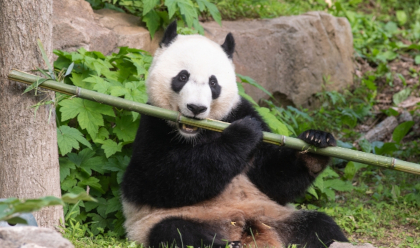

*By **Thibault Bétrémieux**, Data Scientist at port-neo Freiburg GmbH (part of port-neo GmbH), thibault.betremieux@port-neo.com*

This is a presentation for the Python User Group Freiburg, see [Meetup Link](https://www.meetup.com/fr-FR/Python-User-Group-Freiburg/events/275586196/).

**[Link to the resources](https://github.com/ThibTrip/thib/tree/master/2021/pandas_crash_course)**

## Part 1 of the Meetup

1. Introduction: explanations on the main structures of the pandas API (Series, DataFrame, indices, data types), resources that can help you
2. I/O: read from/save to csv, Excel, SQL, ... BONUS: SQL records update using DataFrames
3. Selecting rows/columns
4. Basic math operations
5. Some common DataFrame operations e.g. handling duplicates, missing values

## Part 2 of the Meetup (T.B.A.)

6. String operations

7. Time operations

8. Transformations: concatenate, groupby, pivot, pivot_table, stack

9. Using custom functions: map, apply, applymap

10. Outside of scope: things you should know about that I won't present in detail

```
- pandas' method chaining super power
- categoricals
- plotting
- styling
```

# 1. Introduction

## 1.1. What is pandas and what can you do with it

> pandas is a software library written for the Python programming language for data manipulation and analysis. In particular, it offers data structures and operations for manipulating numerical tables and time series.

> (Source: [Wikipedia](https://en.wikipedia.org/wiki/Pandas_%28software%29))

pandas was created by Wes McKinney.

Amongst many other things pandas allows you to:

- **read from and save to** many formats (csv, excel, SQL, feather, parquet, ...)
- do fast vectorized operations (e.g. column1 + column2) with lots of already integrated math/stats methods
- transform data by grouping (similar to SQL GROUP BY), pivoting, stacking (columns to rows) and unstacking, ...
- apply your own functions element wise or vector wise
- work with strings and datetimes easely (e.g. `pd.Series.str.strip`, `pd.Series.dt.month`, ...)
- deal with duplicates and null values
- plot
- present tables with pretty styling 🦄

If used correctly (i.e. in a vectorized and optimized manner) it can be very fast. It actually uses `C` extensions which speeds up operations.

## 1.2. What you can't do (or do well) with pandas

### 1.2.1. Working with massive datasets

You can't transform very big tabular data at once (e.g. a dataset of 100GB) since you'd have to fit it in memory. But there are easy ways to overcome such situations

- work with pandas in chunks (read chunk, process chunk, save chunk)
- pandas + something else. E.g. dump the data in a SQL database and load an aggregated version of it in pandas where you will do additional transformations.
- something else e.g. [ibis](http://ibis-project.org/) which combines Python syntax with SQL. Or simply SQL (I myself use PostgreSQL a lot 🐘)
- using libraries such as [dask](https://docs.dask.org/en/latest/dataframe.html). `dask` is **lazy** and only does the computations on the dataset when needed
- see also [page "Scaling to large datasets" in pandas docs](https://pandas.pydata.org/pandas-docs/stable/user_guide/scale.html)

### 1.2.2. Structures with many dimensions

Working with structures with more dimensions that just a plain table with rows and columns will be tough with pandas. E.g. something like an OLAP cube:

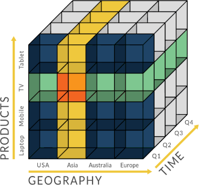

The example above could still work in pandas because you can use multiple levels of columns and indices but it would start to get tricky 🤔. For such structures you can use [xarray](http://xarray.pydata.org/).

## 1.3. Installation

`pip install pandas` or `conda install pandas` (if you use `conda`)

This tutorial uses the most recent version of pandas which is **`1.2.1`** at this time.

## 1.4. Recommandations

When starting/updating a script/module/library I recommand using `pandas` in an interactive environment such as [Jupyter Lab](https://jupyter.org/) where you can **watch and document the transformation of a table** which makes it very easy to troubleshoot problems. The easiest way to install `Jupyter Lab` is to enter `pip install jupyterlab` but I recommand installing [Anaconda](https://www.anaconda.com/products/individual) which is a bundle containing Python, Jupyter, the conda package and environment manager and lots of other very useful tools for data science.

With my favorite extension for `Jupyter Lab` called jupytext you can even **work with Python text files interactively, as if they were notebooks**. This allows you to develop modules or even libraries which I do myself very often. I talked about it during my last [presentation](https://thibtrip.github.io/lightning_talks/#/5).

## 1.5. Highly recommanded resources

- [The new pandas documentation](https://pandas.pydata.org/docs/getting_started/index.html): I've linked here the **"Getting started"** page which is well illustrated but the whole documentation is really awesome (also the reference for functions/methods etc, despite some abstract examples sometimes)

**WARNING:** in the resources below some things may be outdated and some things can now be done more efficiently or with a shorter code but those are still great resources nonetheless.

- data school ([website](https://www.dataschool.io/easier-data-analysis-with-pandas/) | [YouTube channel](https://www.youtube.com/c/dataschool/featured)): topics on pandas that are very well explained and presented in video
- [Python for Data Analysis Book](https://wesmckinney.com/pages/book.html) **by the author of pandas**: make sure to get the latest edition (2nd at the time I am writing this)! This is not as easy as the data school videos but it's very helpful

Since `pandas` is a very popular library, **most questions** (especially basic ones) are just **one google query away**. And most of the time you will propbably end up on a **stackoverflow** thread 🙈 or the **pandas documentation**.

## 1.6. Structures

### 1.6.1. `pd.Series`

> Series is a one-dimensional labeled array capable of holding any data type (integers, strings, floating point numbers, Python objects, etc.). The axis labels are collectively referred to as the index.

> (Source: [pandas docs](https://pandas.pydata.org/pandas-docs/stable/user_guide/dsintro.html))

This can be compared to a dictionary. Unlike the dictionary the index allows duplicate by default! A [new experimental feature](https://pandas.pydata.org/docs/whatsnew/v1.2.0.html#optionally-disallow-duplicate-labels) exists to check that automatically on subsequent operations.

#### Creating a Series from scratch

```python
import pandas as pd

s = pd.Series(['Thibault', 'John'])
s
```

```
0    Thibault
1        John
dtype: object
```

```python
s.index
```

```
RangeIndex(start=0, stop=2, step=1)
```

```python
s.values
```

```
array(['Thibault', 'John'], dtype=object)
```

you can provide a name for the Series, a different index than the default one (range from 0 to the length of the DataFrame minus one) and even name the index

```python
s = pd.Series(data=['Thibault', 'John'], index=['a', 'b'], name='firstname')
s.index.name = 'id'
s
```

```
id
a    Thibault
b        John
Name: firstname, dtype: object
```

```python
pd.Series(data={'a':'Thibault', 'b':'John'}, # a dict {index:value} also works
          name='firstname').rename_axis(index='id')
```

```
id
a    Thibault
b        John
Name: firstname, dtype: object
```

```python
s.dtype # 'O' stands for "object", more on that later
```

```
dtype('O')
```

#### Notes on data types

wondering why the data type of our Series is "O" (**"object"**) and not something like **"string"** or "str"? `pandas` uses lots of `numpy` arrays in the backend and `numpy` does not have a string data type for arrays.

By the way `numpy` arrays are similar to python lists but they are typed which allows for much faster vectorized operations (more on that later). And `numpy` uses `C` extensions which is faster than Python.

```python
type(s.values) # yep it's a numpy array
```

```
numpy.ndarray
```

But pandas has developped so called extension arrays (they extend numpy arrays) where a **"string"** data type exists. You can start using them already by using the method `convert_dtypes`

Why it matters:

- the numpy "object" dtype (data type) is not specific to strings so it can contain other things
- pandas' string data type will only allow string or null
- it's clear what it is (string and not something else)

```python
s = s.convert_dtypes()
s
```

```
id
a    Thibault
b        John
Name: firstname, dtype: string
```

```python
s.dtype # StringDtype is an extension array of pandas
```

```
StringDtype
```

### 1.6.2. `pd.DataFrame`

> Data structure also contains labeled axes (rows and columns) [...] Can be thought of as a dict-like container for Series objects. The primary pandas data structure.

> (Source: [pd.DataFrame docstring](https://pandas.pydata.org/pandas-docs/stable/reference/api/pandas.DataFrame.html))

#### Creating a DataFrame from scratch

I'll use different ways to create DataFrames later. Pandas can ingest many different things 🐼.

Like `pd.Series` you can put pretty much any type of data you want in a DataFrame (float, int, complex numbers, tuple, list, str, ...).

```python
data = {'first_name':['Alex', 'John'],
        'number_of_cars':[0, 2],
        'is_subscribed_to_newsletter':[False, True],
        'interests':[['pizza', 'traveling'], ['movies']]}
df = pd.DataFrame(data=data)
df
```

|  | first_name | number_of_cars | is_subscribed_to_newsletter | interests |
| --- | --- | --- | --- | --- |
| 0 | Alex | 0 | False | [pizza, traveling] |
| 1 | John | 2 | True | [movies] |

```python
df.index
```

```
RangeIndex(start=0, stop=2, step=1)
```

```python
df.columns
```

```
Index(['first_name', 'number_of_cars', 'is_subscribed_to_newsletter',
       'interests'],
      dtype='object')
```

## Data types

```python
df.dtypes
```

```
first_name                     object
number_of_cars                  int64
is_subscribed_to_newsletter      bool
interests                      object
dtype: object
```

```python
# I'd suggest using the new data types here as well
df = df.convert_dtypes()
df.dtypes
```

```
first_name                      string
number_of_cars                   Int64
is_subscribed_to_newsletter    boolean
interests                       object
dtype: object
```

#### The columns of the DataFrame are in fact Series 😳

```python
df['first_name'] # selects the column "first_name"
```

```
0    Alex
1    John
Name: first_name, dtype: string
```

```python
type(df['first_name'])
```

```
pandas.core.series.Series
```

### 1.6.3. Notes on indices and labels

- The index of a Series or a DataFrame can have multiple levels
- The columns of a DataFrame can have multiple levels
- A DataFrame can also receive a name for each column level and a name for the index. Yes I know it's confusing 🐒

Some operations may return a Series or DataFrame with multidimensional headers or indices (e.g. pivot, stack) so do not be surprised! Here is an example which we won't work with because we'd need much more time if we wanted to learn about selecting and operating on DataFrames with multidimensional headers/indices

```python
import numpy as np
index = pd.MultiIndex.from_product([[2020, 2021], ['Freiburg', 'Lindau']], names=['year', 'location'])
columns = pd.MultiIndex.from_product([['Superstore', 'Alnatura'], ['cosmetics', 'food']], names=['store', 'product_type'])
data = np.random.randint(low=10000, high=900000, size=(len(index),len(columns)))
df = pd.DataFrame(data=data, index=index, columns=columns)
# add a label for the whole index (not labels for each level which we have already)
df.index.name = 'my_index'
df
```

| year | store product_type location | Superstore cosmetics | Superstore food | Alnatura cosmetics | Alnatura food |
| --- | --- | --- | --- | --- | --- |
| 2020 | Freiburg | 266688 | 848976 | 447273 | 304739 |
|  | Lindau | 728727 | 644237 | 756807 | 760880 |
| 2021 | Freiburg | 433826 | 765350 | 479932 | 113527 |
|  | Lindau | 799855 | 283576 | 467882 | 302953 |

```python
# it's surprising pandas doesn't show the index name but only the names of the levels, but as you can see it's here
print(f'index name: {df.index.name}')
print(f'names of index levels: {df.index.names}')
```

```
index name: my_index
names of index levels: ['year', 'location']
```

The behavior of some operations changes with multidimensional headers and indices.

For instance when using the syntax I mentioned before for selecting a column we get a DataFrame back in the example below (a subset of our DataFrame to be precise) and not a Series

```python
df['Superstore']
```

| year | product_type location | cosmetics | food |
| --- | --- | --- | --- |
| 2020 | Freiburg | 266688 | 848976 |
|  | Lindau | 728727 | 644237 |
| 2021 | Freiburg | 433826 | 765350 |
|  | Lindau | 799855 | 283576 |

See also this [example](https://github.com/ThibTrip/thib/blob/master/2021/pandas_crash_course/examples/merge/question_pandas_merge.ipynb) on a question about merge operation Lilia Schuster asked me!

The transformation is a bit complicated but the **multidimensional DataFrame** output at cell **`[5]`** is particularly interesting.

### 1.6.4. ⚠️ The index is a separate entity and cannot be selected like columns!

```python
import traceback

df = pd.DataFrame({'name':['Tibaldo', 'John']}, index=pd.Index([100, 200], name='id'))
display(df) # pretty print function implicitely imported when using Jupyter/IPython (from IPython.display import display)

try:
    df['id']
except KeyError:
    traceback.print_exc()

df.index # <-- select like this (and if you have multiple levels use df.index.get_level_values('id'))
```

| id | name |
| --- | --- |
| 100 | Tibaldo |
| 200 | John |

```
Traceback (most recent call last):
  File "/home/tibaldo/anaconda3/envs/lab-env/lib/python3.8/site-packages/pandas/core/indexes/base.py", line 2891, in get_loc
    return self._engine.get_loc(casted_key)
  File "pandas/_libs/index.pyx", line 70, in pandas._libs.index.IndexEngine.get_loc
  File "pandas/_libs/index.pyx", line 101, in pandas._libs.index.IndexEngine.get_loc
  File "pandas/_libs/hashtable_class_helper.pxi", line 1675, in pandas._libs.hashtable.PyObjectHashTable.get_item
  File "pandas/_libs/hashtable_class_helper.pxi", line 1683, in pandas._libs.hashtable.PyObjectHashTable.get_item
KeyError: 'id'

The above exception was the direct cause of the following exception:

Traceback (most recent call last):
  File "<ipython-input-21-1789fb35f70c>", line 7, in <module>
    df['id']
  File "/home/tibaldo/anaconda3/envs/lab-env/lib/python3.8/site-packages/pandas/core/frame.py", line 2902, in __getitem__
    indexer = self.columns.get_loc(key)
  File "/home/tibaldo/anaconda3/envs/lab-env/lib/python3.8/site-packages/pandas/core/indexes/base.py", line 2893, in get_loc
    raise KeyError(key) from err
KeyError: 'id'
```

```
Int64Index([100, 200], dtype='int64', name='id')
```

# 2. I/O (Input/Output)

**WARNING**: with csv and excel files (and any kind of file that does not contain data type indications actually) pandas infers data types. Values such as `01234` will be interpreted as `1234`. If it was a zip code it is now wrong.

Use the parameter **`dtype`** to circumvent this as I'll show in the examples or use the [gist](https://gist.github.com/ThibTrip/55fce86de023c98b9379de2f9be58249) I made for that which will infer which columns should be kept as string by using some custom rules.

## 2.1. CSV files

Explanations on some parameters you'll probably use at some point:

- `sep`: delimiter, by default `","` but in Germany it is often `";"`
- `encoding`: in Germany it is sometimes "iso-8859-1" (encoding can be detected with chardet if needed)
- **`dtype`**: which data type pandas should use for columns e.g. `string` (all the columns as the String data type) or `{'zip_code':'string'}` (the column "zip_code" as the String data type, for the rest we let pandas infer it)
- `index_col`: which column(s) to use as index
- `usecols` for selecting only some columns
- `chunksize`: yields n rows at a time (gives back an iterator), this is great for working on huge files in chunks
- `skiprows`: list-like of line numbers or number of lines to skip (or callable)

Obviously there are many more parameters e.g. I remember tweaking `na_values` and `keep_default_na` for working with geographic data to avoid `NA` (Namibia) being interpreted as a NULL value 🙈.

```python
# read from csv
df = pd.read_csv('./data/example.csv', sep=';', dtype={'zip_code':'string', 'phone_number':'string'}, index_col='id')

# save to csv (let's assume you'll want ';' as a separator as well here)
df.to_csv('./data/example.csv', sep=';')

df
```

| id | first_name | last_website_visit | number_of_cars | is_subscribed_to_newsletter | zip_code | phone_number |
| --- | --- | --- | --- | --- | --- | --- |
| 100 | Alex | 2020-01-01 10:01:02 | 0 | False | 01234 | +999 |
| 200 | John | 2020-01-01 20:07:10 | 2 | True | 12345 | +222 |

you can read directly from a URL too (ftp, s3 and more URL schemes are also supported). Most read and save methods also handle **compression**. Note that reading from archives only works if there is only one file in the archive (but it's easy to [use a file handle to select files](https://stackoverflow.com/a/44118138))

```python
df = pd.read_csv('http://download.geonames.org/export/dump/cities15000.zip',
                 header=None, # the first row is not a header, I'll provide my own names (see below)
                 names=['geonameid', 'name', 'asciiname', 'alternatenames', 'latitude', 'longitude', 'feature class',
                        'feature code', 'country code', 'cc2', 'admin1 code', 'admin2 code', 'admin3 code', 'admin4 code',
                        'population', 'elevation', 'dem', 'timezone', 'modification date'],
                 sep='\t') # tabulation

df = df.convert_dtypes().set_index('geonameid')
df
```

| geonameid | name | asciiname | alternatenames | latitude | longitude | feature class | feature code | country code | cc2 | admin1 code | admin2 code | admin3 code | admin4 code | population | elevation | dem | timezone | modification date |
| --- | --- | --- | --- | --- | --- | --- | --- | --- | --- | --- | --- | --- | --- | --- | --- | --- | --- | --- |
| 3040051 | les Escaldes | les Escaldes | Ehskal'des-Ehndzhordani,Escaldes,Escaldes-Engo... | 42.50729 | 1.53414 | P | PPLA | AD | <NA> | 08 | <NA> | <NA> | <NA> | 15853 | <NA> | 1033 | Europe/Andorra | 2008-10-15 |
| 3041563 | Andorra la Vella | Andorra la Vella | ALV,Ando-la-Vyey,Andora,Andora la Vela,Andora ... | 42.50779 | 1.52109 | P | PPLC | AD | <NA> | 07 | <NA> | <NA> | <NA> | 20430 | <NA> | 1037 | Europe/Andorra | 2020-03-03 |
| 290594 | Umm Al Quwain City | Umm Al Quwain City | Oumm al Qaiwain,Oumm al Qaïwaïn,Um al Kawain,U... | 25.56473 | 55.55517 | P | PPLA | AE | <NA> | 07 | <NA> | <NA> | <NA> | 62747 | <NA> | 2 | Asia/Dubai | 2019-10-24 |
| 291074 | Ras Al Khaimah City | Ras Al Khaimah City | Julfa,Khaimah,RAK City,RKT,Ra's al Khaymah,Ra'... | 25.78953 | 55.94320 | P | PPLA | AE | <NA> | 05 | <NA> | <NA> | <NA> | 351943 | <NA> | 2 | Asia/Dubai | 2019-09-09 |
| 291580 | Zayed City | Zayed City | Bid' Zayed,Bid’ Zayed,Madinat Za'id,Madinat Za... | 23.65416 | 53.70522 | P | PPL | AE | <NA> | 01 | 103 | <NA> | <NA> | 63482 | <NA> | 124 | Asia/Dubai | 2019-10-24 |
| ... | ... | ... | ... | ... | ... | ... | ... | ... | ... | ... | ... | ... | ... | ... | ... | ... | ... | ... |
| 894701 | Bulawayo | Bulawayo | BUQ,Bulavajas,Bulavajo,Bulavejo,Bulawayo,bu la... | -20.15000 | 28.58333 | P | PPLA | ZW | <NA> | 09 | <NA> | <NA> | <NA> | 699385 | <NA> | 1348 | Africa/Harare | 2019-09-05 |
| 895061 | Bindura | Bindura | Bindura,Bindura Town,Kimberley Reefs,Биндура | -17.30192 | 31.33056 | P | PPLA | ZW | <NA> | 03 | <NA> | <NA> | <NA> | 37423 | <NA> | 1118 | Africa/Harare | 2010-08-03 |
| 895269 | Beitbridge | Beitbridge | Bajtbridz,Bajtbridzh,Beitbridge,Beitbridzas,Be... | -22.21667 | 30.00000 | P | PPL | ZW | <NA> | 07 | <NA> | <NA> | <NA> | 26459 | <NA> | 461 | Africa/Harare | 2013-03-12 |
| 1085510 | Epworth | Epworth | Epworth | -17.89000 | 31.14750 | P | PPLX | ZW | <NA> | 10 | <NA> | <NA> | <NA> | 123250 | <NA> | 1508 | Africa/Harare | 2012-01-19 |
| 1106542 | Chitungwiza | Chitungwiza | Chitungviza,Chitungwiza,Chytungviza,Citungviza... | -18.01274 | 31.07555 | P | PPL | ZW | <NA> | 10 | <NA> | <NA> | <NA> | 340360 | <NA> | 1435 | Africa/Harare | 2019-09-05 |

24546 rows × 18 columns

## 2.2. Excel files

Apart from `sep` and `encoding` this method also has the parameters I mentioned above.

A very important argument here is `sheet_name` to select which sheet of the excel file you want to read.

You'll have to install `openpyxl` for reading and writing Excel files (`pip install openpyxl`). Openpyxl is pretty cool. I've used it a few times to list sheet names, check out which sheet are hidden, how cells are formatted etc. Here is for instance an [Openpyxl tutorial](https://zetcode.com/python/openpyxl/) showing some of the possibilities.

If working with `.xls` files (as opposed to `.xlsx`) you'll have to use `xlrd` (`pip install xlrd`).

```python
df = pd.read_excel('./data/example.xlsx', dtype={'zip_code':'string', 'phone_number':'string'}, index_col='id',
                   sheet_name='example') # if not provided, the first sheet is read

# save to excel
df.to_excel('./data/example.xlsx', sheet_name='example') # default sheet name is "Sheet1"

df
```

| id | first_name | last_website_visit | number_of_cars | is_subscribed_to_newsletter | zip_code | phone_number |
| --- | --- | --- | --- | --- | --- | --- |
| 100 | Alex | 2020-01-01 10:01:02 | 0 | False | 01234 | +999 |
| 200 | John | 2020-01-01 20:07:10 | 2 | True | 12345 | +222 |

## 2.3. SQL

We use the library `sqlalchemy` for creating an object to communicate with the database (see `engine` below).

The `sqlalchemy.create_engine` function we use below takes a [connection string to a database](https://docs.sqlalchemy.org/en/latest/core/engines.html).

For example, the syntax for PostgreSQL (it's similar for most other databases) is as follows:

```
connection_string = f'postgresql://{USERNAME}:{PASWORD}@{HOST}:{PORT}/{DB}'
```

```python
from sqlalchemy import create_engine # pip install sqlalchemy

# sqlite is a bit of special SQL flavor since the database is on the disk (so you just provide a path)
connection_string = 'sqlite:///./data/db.sqlite3'
engine = create_engine(connection_string)

df = pd.read_sql(sql='SELECT * FROM people;', con=engine, index_col='id')
df
```

| id | first_name | last_website_visit | number_of_cars | is_subscribed_to_newsletter | zip_code | phone_number |
| --- | --- | --- | --- | --- | --- | --- |
| 100 | Alex | 2020-01-01 10:01:02.000000 | 0 | 0 | 01234 | +999 |
| 200 | John | 2020-01-01 20:07:10.000000 | 2 | 1 | 12345 | +222 |

Saving to SQL

```python
df.to_sql(name='people',
          con=engine,
          index=True, # default, we want to save the index
          if_exists='replace', # what to do if the table exists (default is "fail" which raises an Exception) and there is also "append"
          method='multi') # IMPORTANT!!!! Otherwise inserts row by row which is super slow
```

**Important tip**: I made a [benchmark of df.to_sql](https://gist.github.com/ThibTrip/b0a752c7b7b1756d87832a5bb48a165b) for PostgreSQL with many methods and as you'll see there are huge differences: from 2min 48 for the slowest method down to **16.1s** for the fastest method!

### Bonus: updating rows in a SQL table with a DataFrame thanks to my library pangres

You will need a **primary key** (or a unique key) which is one or multiple columns for identifying records. The primary key will have to be set as index in the pandas DataFrame.

The example demonstrates what the library can do, but you'll definitely need the [documentation](https://github.com/ThibTrip/pangres/wiki).

load some table I saved in the database

```python
from sqlalchemy import create_engine # pip install sqlalchemy
from pangres import upsert # pip install pangres
engine = create_engine('sqlite:///./data/db.sqlite3') # "./data/db.sqlite3" is the path to a SQlite3 database
df = pd.read_sql('SELECT * FROM pangres_test;', con=engine, index_col='id').convert_dtypes()
df
```

| id | first_name | number_of_cars |
| --- | --- | --- |
| 100 | John | 2 |
| 200 | Thibault | 1 |

create some new data to update and insert

```python
new_df = pd.DataFrame({'id':[200, 300], 'first_name':['Lord Thibault', 'Alex'], 'number_of_cars':[30, 1], 'number_of_houses':[5, 2]}).set_index('id')
new_df
```

| id | first_name | number_of_cars | number_of_houses |
| --- | --- | --- | --- |
| 200 | Lord Thibault | 30 | 5 |
| 300 | Alex | 1 | 2 |

upsert (insert update) the new data and check what is in the table

```python
upsert(engine=engine, df=new_df, table_name='pangres_test', if_row_exists='update', add_new_columns=True)
pd.read_sql('SELECT * FROM pangres_test;', con=engine, index_col='id').convert_dtypes()
```

```
2021-01-30 22:22:45,467 | INFO     | pangres    | logger:log:48 - Added column pangres_test.number_of_houses (type: BIGINT) in table pangres_test (schema="None")
2021-01-30 22:22:45,469 | INFO     | pangres    | logger:log:37 - Reduced chunksize from 10000 to 249 due to SQlite max variable restriction (max 999).
```

| id | first_name | number_of_cars | number_of_houses |
| --- | --- | --- | --- |
| 100 | John | 2 | <NA> |
| 200 | Lord Thibault | 30 | 5 |
| 300 | Alex | 1 | 2 |

## 2.4. Pickles

While you can use `joblib` to store a Python session on disk, I find pickles really interesting for simply exchanging a few DataFrames (amongst other things) between notebooks.

For pickling other things than DataFrames see [this stackoverflow post](https://stackoverflow.com/a/11218504).

[figure not shown]

```python
df = pd.read_pickle('./data/df.pickle') # note: this will work on any kind of pickled object if you are lazy 🐒 (so not just DataFrames)
df.to_pickle('./data/df.pickle')
df
```

| id | first_name | last_website_visit | number_of_cars | is_subscribed_to_newsletter | zip_code | phone_number |
| --- | --- | --- | --- | --- | --- | --- |
| 100 | Alex | 2020-01-01 10:01:02 | 0 | False | 01234 | +999 |
| 200 | John | 2020-01-01 20:07:10 | 2 | True | 12345 | +222 |

## 2.5. HTML

`pd.read_html` always returns a list of DataFrames: one DataFrame for each table that can be found on given website or HTML code

Example: grab the german region codes (ISO 3166-2) from Wikipedia

```python
dfs = pd.read_html('https://en.wikipedia.org/wiki/ISO_3166-2:DE')
dfs[0].set_index('Code')
```

| Code | Subdivision Name (de) | Subdivision Name (en)[note 1] |
| --- | --- | --- |
| DE-BW | Baden-Württemberg | Baden-Württemberg |
| DE-BY | Bayern | Bavaria |
| DE-BE | Berlin | Berlin |
| DE-BB | Brandenburg | Brandenburg |
| DE-HB | Bremen | Bremen |
| DE-HH | Hamburg | Hamburg |
| DE-HE | Hessen | Hesse |
| DE-MV | Mecklenburg-Vorpommern | Mecklenburg-Western Pomerania |
| DE-NI | Niedersachsen | Lower Saxony |
| DE-NW | Nordrhein-Westfalen | North Rhine-Westphalia |
| DE-RP | Rheinland-Pfalz | Rhineland-Palatinate |
| DE-SL | Saarland | Saarland |
| DE-SN | Sachsen | Saxony |
| DE-ST | Sachsen-Anhalt | Saxony-Anhalt |
| DE-SH | Schleswig-Holstein | Schleswig-Holstein |
| DE-TH | Thüringen | Thuringia |

## 2.6. Many more file types are handled by pandas

JSON, stata, parquet, feather, HD5F... See [I/O page](https://pandas.pydata.org/pandas-docs/stable/reference/io.html) of the documentation.

## 2.7. Pro tip: `pd.json_normalize`

The function `pd.json_normalize` allows you to quickly parse data from APIs that use JSON

```python
import requests, json
# get facts on cats from a free public API
response = requests.get('https://cat-fact.herokuapp.com/facts')
json_data = response.text
json_data[0:500] + '...' # let's just display a part of the JSON string
```

```
'[{"status":{"verified":true,"sentCount":1,"feedback":""},"type":"cat","deleted":false,"_id":"5887e1d85c873e0011036889","user":"5a9ac18c7478810ea6c06381","text":"Cats make about 100 different sounds. Dogs make only about 10.","__v":0,"source":"user","updatedAt":"2020-09-03T16:39:39.578Z","createdAt"…
```

```python
json_data_loaded = json.loads(json_data)
json_data_loaded[0]
```

```
{'status': {'verified': True, 'sentCount': 1, 'feedback': ''},
 'type': 'cat',
 'deleted': False,
 '_id': '5887e1d85c873e0011036889',
 'user': '5a9ac18c7478810ea6c06381',
 'text': 'Cats make about 100 different sounds. Dogs make only about 10.',
 '__v': 0,
 'source': 'user',
 'updatedAt': '2020-09-03T16:39:39.578Z',
 'createdAt': '2018-01-15T21:20:00.003Z',
 'used': True}
```

Use `pd.json_normalize` on the data we just acquired and loaded as JSON

There are very useful arguments in this function e.g. `record_path` to precise which json key holds the records.

Notice the two coluns `status.verified` and `status.sentCount` which came from a structure like this:

```
{'status': {'verified': True, 'sentCount': 1}}
```

The `.` shows the different nodes (you can modify the symbol with the argument `sep`).

```python
df = pd.json_normalize(json_data_loaded) #
df.head(2) # display the first 2 rows (by default it is 5)
```

|  | type | deleted | _id | user | text | __v | source | updatedAt | createdAt | used | status.verified | status.sentCount | status.feedback |
| --- | --- | --- | --- | --- | --- | --- | --- | --- | --- | --- | --- | --- | --- |
| 0 | cat | False | 5887e1d85c873e0011036889 | 5a9ac18c7478810ea6c06381 | Cats make about 100 different sounds. Dogs mak... | 0 | user | 2020-09-03T16:39:39.578Z | 2018-01-15T21:20:00.003Z | True | True | 1 |  |
| 1 | cat | False | 588e746706ac2b00110e59ff | 588e6e8806ac2b00110e59c3 | Domestic cats spend about 70 percent of the da... | 0 | user | 2020-08-26T20:20:02.359Z | 2018-01-14T21:20:02.750Z | True | True | 1 | NaN |

```python
df = pd.read_json('https://cat-fact.herokuapp.com/facts')
df.head()
```

|  | status | type | deleted | _id | user | text | __v | source | updatedAt | createdAt | used |
| --- | --- | --- | --- | --- | --- | --- | --- | --- | --- | --- | --- |
| 0 | {'verified': True, 'sentCount': 1, 'feedback':... | cat | False | 5887e1d85c873e0011036889 | 5a9ac18c7478810ea6c06381 | Cats make about 100 different sounds. Dogs mak... | 0 | user | 2020-09-03T16:39:39.578Z | 2018-01-15T21:20:00.003Z | True |
| 1 | {'verified': True, 'sentCount': 1} | cat | False | 588e746706ac2b00110e59ff | 588e6e8806ac2b00110e59c3 | Domestic cats spend about 70 percent of the da... | 0 | user | 2020-08-26T20:20:02.359Z | 2018-01-14T21:20:02.750Z | True |
| 2 | {'verified': True, 'sentCount': 1} | cat | False | 58923f2fc3878c0011784c79 | 5887e9f65c873e001103688d | I don't know anything about cats. | 0 | user | 2020-08-23T20:20:01.611Z | 2018-02-25T21:20:03.060Z | False |
| 3 | {'verified': True, 'sentCount': 1} | cat | False | 5894af975cdc7400113ef7f9 | 5a9ac18c7478810ea6c06381 | The technical term for a cat’s hairball is a b... | 0 | user | 2020-11-25T21:20:03.895Z | 2018-02-27T21:20:02.854Z | True |
| 4 | {'verified': True, 'sentCount': 1} | cat | False | 58e007cc0aac31001185ecf5 | 58e007480aac31001185ecef | Cats are the most popular pet in the United St... | 0 | user | 2020-08-23T20:20:01.611Z | 2018-03-01T21:20:02.713Z | False |

# 3. Selecting rows/columns

## Let's make an example DataFrame

Yes the index is not alphabetically sorted, this is on purpose 🐒

```python
records = [['Alex', 0, False, 1],
           ['John', 2, True, 1],
           ['Thib', 0, True, 2],
           ['Arnold', 2, True, 1]]
columns = ['first_name', 'number_of_cars', 'is_subscribed_to_newsletter', 'number_of_houses']
index = pd.Index(data=(400, 265, 450, 122), name='id')

df = pd.DataFrame(data=records, columns=columns, index=index)
df
```

| id | first_name | number_of_cars | is_subscribed_to_newsletter | number_of_houses |
| --- | --- | --- | --- | --- |
| 400 | Alex | 0 | False | 1 |
| 265 | John | 2 | True | 1 |
| 450 | Thib | 0 | True | 2 |
| 122 | Arnold | 2 | True | 1 |

## 3.1. `df.head()` and `df.tail()`

head displays the first n rows of a DataFrame (by default 5)

```python
df.head(2)
```

| id | first_name | number_of_cars | is_subscribed_to_newsletter | number_of_houses |
| --- | --- | --- | --- | --- |
| 400 | Alex | 0 | False | 1 |
| 265 | John | 2 | True | 1 |

tail displays the last n rows of a DataFrame (by default 5)

```python
df.tail(2)
```

| id | first_name | number_of_cars | is_subscribed_to_newsletter | number_of_houses |
| --- | --- | --- | --- | --- |
| 450 | Thib | 0 | True | 2 |
| 122 | Arnold | 2 | True | 1 |

## 3.2. simple column selection

```python
df['first_name'] # I selected one label via a string -> returns a Series
```

```
id
400      Alex
265      John
450      Thib
122    Arnold
Name: first_name, dtype: object
```

```python
df[['first_name', 'number_of_cars']] # mutiple columns -> returns a DataFrame
```

| id | first_name | number_of_cars |
| --- | --- | --- |
| 400 | Alex | 0 |
| 265 | John | 2 |
| 450 | Thib | 0 |
| 122 | Arnold | 2 |

```python
df[['first_name']] # I selected one label but via a list -> also returns a DataFrame
```

| id | first_name |
| --- | --- |
| 400 | Alex |
| 265 | John |
| 450 | Thib |
| 122 | Arnold |

## 3.3. selection by labels (`df.loc`)

This works by using `df.loc`. The basic syntax is `df.loc[rows (indices), columns]`

```python
indices = [400, 265]
columns = ['first_name', 'number_of_cars']
df.loc[indices, columns]
```

| id | first_name | number_of_cars |
| --- | --- | --- |
| 400 | Alex | 0 |
| 265 | John | 2 |

slices are also allowed (they are somewhat similar to slices with lists)

```python
df.loc[:, ['first_name', 'number_of_cars']] # all rows and the columns "first_name" and "number_of_cars"
```

| id | first_name | number_of_cars |
| --- | --- | --- |
| 400 | Alex | 0 |
| 265 | John | 2 |
| 450 | Thib | 0 |
| 122 | Arnold | 2 |

```python
df.loc[400:450, :] # rows from label 400 to label 450
```

| id | first_name | number_of_cars | is_subscribed_to_newsletter | number_of_houses |
| --- | --- | --- | --- | --- |
| 400 | Alex | 0 | False | 1 |
| 265 | John | 2 | True | 1 |
| 450 | Thib | 0 | True | 2 |

```python
df.loc[:, 'first_name':'is_subscribed_to_newsletter'] # columns from label "first_name" until label "is_subscribed_to_newsletter"
```

| id | first_name | number_of_cars | is_subscribed_to_newsletter |
| --- | --- | --- | --- |
| 400 | Alex | 0 | False |
| 265 | John | 2 | True |
| 450 | Thib | 0 | True |
| 122 | Arnold | 2 | True |

⚠️ if you select a single row label or a single column label a Series is returned

```python
df.loc[400, :]
```

```
first_name                      Alex
number_of_cars                     0
is_subscribed_to_newsletter    False
number_of_houses                   1
Name: 400, dtype: object
```

```python
df.loc[[400], :] # see how this returns a DataFrame even with a single row label just because I put a list
```

| id | first_name | number_of_cars | is_subscribed_to_newsletter | number_of_houses |
| --- | --- | --- | --- | --- |
| 400 | Alex | 0 | False | 1 |

```python
df.loc[:, 'first_name'] # same as df['first_name']
```

```
id
400      Alex
265      John
450      Thib
122    Arnold
Name: first_name, dtype: object
```

🐍 and if you select a single row label AND a single column label you get the value of the cell back.

Here we are effectively selecting a cell and getting the first name of the person with the id 400 (a string)

```python
df.loc[400, 'first_name']
```

```
'Alex'
```

## 3.4. selection by position (`df.iloc`)

```python
index_positions = [0, 2]
columns_positions = [0, 1]
df.iloc[index_positions, columns_positions]
```

| id | first_name | number_of_cars |
| --- | --- | --- |
| 400 | Alex | 0 |
| 450 | Thib | 0 |

you can also use slices here

⚠️ similarly to the standard `range` function `0:2` means only first and second row (not the third one)!

```python
list(range(0, 3)) # this is in case you forgot how range works 🙈
```

```
[0, 1, 2]
```

```python
df.iloc[0:3, :] # rows 0 to 2 included, all columns
```

| id | first_name | number_of_cars | is_subscribed_to_newsletter | number_of_houses |
| --- | --- | --- | --- | --- |
| 400 | Alex | 0 | False | 1 |
| 265 | John | 2 | True | 1 |
| 450 | Thib | 0 | True | 2 |

```python
df.iloc[:, 0:3] # all rows, columns 0 to 2 included
```

| id | first_name | number_of_cars | is_subscribed_to_newsletter |
| --- | --- | --- | --- |
| 400 | Alex | 0 | False |
| 265 | John | 2 | True |
| 450 | Thib | 0 | True |
| 122 | Arnold | 2 | True |

## 3.5. selection by masks (`df.loc`)

⚠️ Use `&` and not `and`!

⚠️ Use `|` and not `or`!

⚠️ Parentheses are important! We are doing comparisons array wise so make sure it is "understandable by Python". There is a WikiPedia article I saw a long time about this logic but I couldn't find it again sorry.

**Bad example**

```
df['money'] > 10000000 or df['first_name'] == 'Thibault'
```

**Good example**

```
(df['money'] > 10000000) & (df['first_name'] == 'Thibault')
```

We'll talk about this weird syntax immediately after but mind the rules above!

tell me for each index value if the number of cars is strictly higher than 0 (i.e. the person has a car)

```python
has_cars = df['number_of_cars'] > 0
has_cars
```

```
id
400    False
265     True
450    False
122     True
Name: number_of_cars, dtype: bool
```

tell me for each index value if is_subscribed_to_newsletter is True

```python
is_subscribed = df['is_subscribed_to_newsletter'] == True
is_subscribed
```

```
id
400    False
265     True
450     True
122     True
Name: is_subscribed_to_newsletter, dtype: bool
```

combine the two conditions in a single series

```python
# combine the two conditions in a single series
# "&" NOT "and" (vector comparison, not element comparison)! Also, no need for parentheses here thanks to the use of variables.
has_cars_and_is_subscribed = has_cars & is_subscribed
has_cars_and_is_subscribed
```

```
id
400    False
265     True
450    False
122     True
dtype: bool
```

same thing as before in one statement

```python
# == True is superfluous for column "is_subscribed_to_newsletter"
# as the label clearly indicates, it's boolean
has_cars_and_is_subscribed = (df['number_of_cars'] > 0) & (df['is_subscribed_to_newsletter'])
has_cars_and_is_subscribed
```

```
id
400    False
265     True
450    False
122     True
dtype: bool
```

get me the rows where the condition is True

```python
df.loc[has_cars_and_is_subscribed, :]
```

| id | first_name | number_of_cars | is_subscribed_to_newsletter | number_of_houses |
| --- | --- | --- | --- | --- |
| 265 | John | 2 | True | 1 |
| 122 | Arnold | 2 | True | 1 |

you can also use masks on columns but this is the kind of thing I rarely use ¯\_(ツ)_/¯

```python
columns_mask = df.columns.str.contains('name') # we will see this "str.contains" "thing" later
print(df.columns.tolist())
print(columns_mask)
df.loc[:, columns_mask]
```

```
['first_name', 'number_of_cars', 'is_subscribed_to_newsletter', 'number_of_houses']
[ True False False False]
```

| id | first_name |
| --- | --- |
| 400 | Alex |
| 265 | John |
| 450 | Thib |
| 122 | Arnold |

# 4. Basic math operations

Let's create some DataFrame. Don't mind the cryptic code to create a random (but realistic) DataFrame of newsletter data it's not very important 🙈

```python
import random, uuid, math

size = 10
index = np.random.choice(['Travel', 'Hotel', 'Restaurant', 'Cinema', 'Theater', 'Cruise'], size=size)
index = pd.Index([f'{cat} Newsletter 2021 #{str(uuid.uuid4()).upper()[:8]}' for cat in index], name='newsletter')
df = pd.DataFrame(index=index)
df['recipients'] = np.random.randint(low=0, high=1500, size=size)
df['impressions'] = df['recipients'].map(lambda v: v//random.uniform(2, 4))
df['clicks'] = df['impressions'].map(lambda v: v//random.uniform(2, 4))
df['soft_bounces'] = df['recipients'].map(lambda v: v//random.uniform(20, 50))
df['hard_bounces'] = df['recipients'].map(lambda v: v//random.uniform(30, 60))
df['unsubscribes'] = df['recipients'].map(lambda v: v//random.uniform(40, 70))
df['author'] = np.random.choice(['John', 'Daniel Z.', 'Alex'], size=size)
# turns out there is a bug with argmax with the new dtype "Int64" that we'll see later
# so let's the old "int" instead
df = df.astype({c:int for c in df.columns if c != 'author'})
df.head()
```

| newsletter | recipients | impressions | clicks | soft_bounces | hard_bounces | unsubscribes | author |
| --- | --- | --- | --- | --- | --- | --- | --- |
| Cruise Newsletter 2021 #5494459A | 1229 | 314 | 124 | 28 | 27 | 30 | Daniel Z. |
| Restaurant Newsletter 2021 #B61F5275 | 1485 | 569 | 196 | 46 | 26 | 26 | John |
| Cruise Newsletter 2021 #8A4EB364 | 289 | 132 | 51 | 8 | 7 | 6 | John |
| Cruise Newsletter 2021 #A1B9D30B | 270 | 118 | 45 | 5 | 5 | 6 | John |
| Cruise Newsletter 2021 #42F1CD67 | 1232 | 441 | 152 | 25 | 38 | 30 | Alex |

## 4.1. Vector to vector operations

dividing

```python
# this creates a new column "clickrate" equals to clicks/recipients
df['clickrate'] = df['clicks'] / df['recipients']
df.head()
```

| newsletter | recipients | impressions | clicks | soft_bounces | hard_bounces | unsubscribes | author | clickrate |
| --- | --- | --- | --- | --- | --- | --- | --- | --- |
| Cruise Newsletter 2021 #5494459A | 1229 | 314 | 124 | 28 | 27 | 30 | Daniel Z. | 0.100895 |
| Restaurant Newsletter 2021 #B61F5275 | 1485 | 569 | 196 | 46 | 26 | 26 | John | 0.131987 |
| Cruise Newsletter 2021 #8A4EB364 | 289 | 132 | 51 | 8 | 7 | 6 | John | 0.176471 |
| Cruise Newsletter 2021 #A1B9D30B | 270 | 118 | 45 | 5 | 5 | 6 | John | 0.166667 |
| Cruise Newsletter 2021 #42F1CD67 | 1232 | 441 | 152 | 25 | 38 | 30 | Alex | 0.123377 |

addition

```python
# addressees are all the people the newsletter was addressed to, no matter if delivery succeeded
df['addressees'] = df['recipients'] + df['soft_bounces'] + df['hard_bounces']
df.head()
```

[output not shown]

you can also use multiplication, substraction, modulo, remainder etc. but I think you get the point

## 4.2. Vector and scalar (single value)

multiply clicks by 1.5 to boost our values 🐒

```python
df['clicks'] * 1.5
```

```
newsletter
Cruise Newsletter 2021 #5494459A        186.0
Restaurant Newsletter 2021 #B61F5275    294.0
Cruise Newsletter 2021 #8A4EB364         76.5
Cruise Newsletter 2021 #A1B9D30B         67.5
Cruise Newsletter 2021 #42F1CD67        228.0
Cinema Newsletter 2021 #D96ED92C        348.0
Travel Newsletter 2021 #62629D73        156.0
Cinema Newsletter 2021 #AA17C4E1        192.0
Theater Newsletter 2021 #5CA7BA89       114.0
Restaurant Newsletter 2021 #A1CB7117     85.5
Name: clicks, dtype: float64
```

while we're at boost the recipients AND the impressions too 🐒 (everything is multiplied by 1.5)

```python
df[['recipients', 'impressions']] * 1.5
```

| newsletter | recipients | impressions |
| --- | --- | --- |
| Cruise Newsletter 2021 #5494459A | 1843.5 | 471.0 |
| Restaurant Newsletter 2021 #B61F5275 | 2227.5 | 853.5 |
| Cruise Newsletter 2021 #8A4EB364 | 433.5 | 198.0 |
| Cruise Newsletter 2021 #A1B9D30B | 405.0 | 177.0 |
| Cruise Newsletter 2021 #42F1CD67 | 1848.0 | 661.5 |
| Cinema Newsletter 2021 #D96ED92C | 1941.0 | 793.5 |
| Travel Newsletter 2021 #62629D73 | 1873.5 | 535.5 |
| Cinema Newsletter 2021 #AA17C4E1 | 2229.0 | 591.0 |
| Theater Newsletter 2021 #5CA7BA89 | 841.5 | 288.0 |
| Restaurant Newsletter 2021 #A1CB7117 | 871.5 | 304.5 |

## 4.3. Calculating sum, average, min, etc.

sum of the values of all rows for given column

```python
df['clicks'].sum()
```

```
1165
```

simple conditional sum

```python
df.loc[df['author'] == 'John', 'clicks'].sum() # sum of clicks for all newsletter authored by John
```

```
425
```

average of clicks across all newsletter

```python
df['clicks'].mean()
```

```
116.5
```

min clicks (so the worst value)

```python
df['clicks'].min()
```

```
45
```

max clicks (so the best value)

```python
df['clicks'].max()
```

```
232
```

show me the best newsletter in term of clicks

```python
best_newsletter_clicks_index = df['clicks'].argmax()
print(f'index of the best newsletter by position: {best_newsletter_clicks_index}')

# I select best_newsletter_clicks_index in a list to get a DataFrame back (it looks prettier)
df.iloc[[best_newsletter_clicks_index],:]
```

```
index of the best newsletter by position: 5
```

[output not shown]

an alternative way of calculating addressees like we did before with:

```
df['recipients'] + df['soft_bounces'] + df['hard_bounces']
```

```python
df[['recipients', 'soft_bounces', 'hard_bounces']].sum(axis='columns')
```

```
newsletter
Cruise Newsletter 2021 #5494459A        1284
Restaurant Newsletter 2021 #B61F5275    1557
Cruise Newsletter 2021 #8A4EB364         304
Cruise Newsletter 2021 #A1B9D30B         280
Cruise Newsletter 2021 #42F1CD67        1295
Cinema Newsletter 2021 #D96ED92C        1361
Travel Newsletter 2021 #62629D73        1313
Cinema Newsletter 2021 #AA17C4E1        1559
Theater Newsletter 2021 #5CA7BA89        582
Restaurant Newsletter 2021 #A1CB7117     605
dtype: int64
```

# 5. Some common DataFrame operations

## 5.1. Important note on assignment

Apart from a few exceptions such as `df.insert` (inserts a new column at a specific position) **most operations in `pandas` require assignment** or the use of the argument **`inplace`** for operations to happen. We will see examples later.

Indeed, most of the times only copies are returned. This is very interesting for:

- vizualizing transformations before executing them
- doing method chaining

## 5.2. Handling duplicates

Let's create a DataFrame with duplicates in a column that we'd want to get rid of

```python
df = pd.DataFrame({'first_name':['Tibaldo', 'Tibaldo', 'John'], 'mothertongue':['French', pd.NA, 'English']})
df
```

|  | first_name | mothertongue |
| --- | --- | --- |
| 0 | Tibaldo | French |
| 1 | Tibaldo | <NA> |
| 2 | John | English |

### Identifying duplicates

```python
df['first_name'].duplicated(keep=False) # or for multiple columns df.duplicates(subset=[col1, col2], keep=False)
```

```
0     True
1     True
2    False
Name: first_name, dtype: bool
```

### Dropping duplicates

as I wrote with the note on the assignment before, here I am just showing what would be the result of the operation (I get a transformed copy of the DataFrame)

```python
df.drop_duplicates(subset=['first_name'], keep='first') # default
```

|  | first_name | mothertongue |
| --- | --- | --- |
| 0 | Tibaldo | French |
| 2 | John | English |

see, the duplicated first name is still here

```python
df
```

|  | first_name | mothertongue |
| --- | --- | --- |
| 0 | Tibaldo | French |
| 1 | Tibaldo | <NA> |
| 2 | John | English |

with the code below it works 🐒!

Note: don't use `inplace` and `subset` together as this would raise a [SettingWithCopyWarning](https://www.dataquest.io/blog/settingwithcopywarning/) (this happens because when calling `drop_duplicates` pandas does some indexing in the background) 🙈🙈

```python
df = df.drop_duplicates(subset=['first_name'], keep='first')
df
```

|  | first_name | mothertongue |
| --- | --- | --- |
| 0 | Tibaldo | French |
| 2 | John | English |

See also the [example notebook](https://github.com/ThibTrip/thib/blob/master/2021/pandas_crash_course/examples/duplicates/isolate_duplicates_excel.ipynb) where I load an Excel table into a pandas DataFrame and save duplicates in it as another Excel file.

This was a question from Irene Sanjay.

## 5.3. Handling nulls

Let's create a DataFrame with NULLs in it

```python
df = pd.DataFrame({'name':['John', 'Alex', 'Daniel'], 'is_client':[True, np.nan, True], 'number_of_cars':[2, pd.NA, pd.NA]}).convert_dtypes()
df
```

|  | name | is_client | number_of_cars |
| --- | --- | --- | --- |
| 0 | John | True | 2 |
| 1 | Alex | <NA> | <NA> |
| 2 | Daniel | True | <NA> |

### Dropping nulls

```python
# drop rows where ANY of the columns mentionned in subset are null
df.dropna(how='any', # default
          subset=['is_client', 'number_of_cars'],
          axis='rows') # default
```

|  | name | is_client | number_of_cars |
| --- | --- | --- | --- |
| 0 | John | True | 2 |

```python
df.dropna(how='all', subset=['is_client', 'number_of_cars']) # drop rows where ALL of the columns mentionned in subset are null
```

|  | name | is_client | number_of_cars |
| --- | --- | --- | --- |
| 0 | John | True | 2 |
| 2 | Daniel | True | <NA> |

### Identifying nulls

#### Scalars

```python
pd.isna('test')
```

```
False
```

```python
pd.isna(None)
```

```
True
```

```python
pd.isna(pd.NaT) # Not a Time, null value for timestamps in pandas
```

```
True
```

```python
pd.isna(np.nan) # numpy nan (not a number, type is float)
```

```
True
```

#### Arrays

```python
df['is_client'].isna()
```

```
0    False
1     True
2    False
Name: is_client, dtype: bool
```

```python
df['is_client'].isna().any()
```

```
True
```

```python
df[['is_client', 'number_of_cars']].isna()
```

|  | is_client | number_of_cars |
| --- | --- | --- |
| 0 | False | False |
| 1 | True | True |
| 2 | False | True |

```python
df[['is_client', 'number_of_cars']].isna().any(axis='columns')
```

```
0    False
1     True
2     True
dtype: bool
```

`pd.isna` also works on lists, tuples etc.

```python
arr_isnull = pd.isna(['a', None])
display(arr_isnull)

arr_isnull.all()
```

```
array([False,  True])
```

```
False
```

## 5.4. Renaming columns/indices

```python
df.rename(columns={'name':'first_name', 'number_of_cars':'number_of_horses'})
```

|  | first_name | is_client | number_of_horses |
| --- | --- | --- | --- |
| 0 | John | True | 2 |
| 1 | Alex | <NA> | <NA> |
| 2 | Daniel | True | <NA> |

```python
df.rename(index={0:999})
```

|  | name | is_client | number_of_cars |
| --- | --- | --- | --- |
| 999 | John | True | 2 |
| 1 | Alex | <NA> | <NA> |
| 2 | Daniel | True | <NA> |

rename accepts functions as well

```python
def rename_column(column):
    # add safety in case we have a non string column
    if isinstance(column, str):
        return column.upper()
    else:
        return column

df.rename(columns=rename_column)
```

|  | NAME | IS_CLIENT | NUMBER_OF_CARS |
| --- | --- | --- | --- |
| 0 | John | True | 2 |
| 1 | Alex | <NA> | <NA> |
| 2 | Daniel | True | <NA> |

Shorter version of the code above with lambda (functions that only need one line). Consider getting familiar with **lambdas** for pandas 🐼. I will make your code shorter.

⚠️ if using `if` in a lambda function, there must be an `else` counterpart

```python
# note: you can do it even shorter with "str.upper" if you assume all column names are strings
df.rename(columns=lambda column: column.upper() if isinstance(column, str) else column)
```

|  | NAME | IS_CLIENT | NUMBER_OF_CARS |
| --- | --- | --- | --- |
| 0 | John | True | 2 |
| 1 | Alex | <NA> | <NA> |
| 2 | Daniel | True | <NA> |

alternatively, you can also replace the column names with an assignment to `df.columns`

```python
df.columns = df.columns.str.upper() # we will see the method `.str.upper` later
df
```

|  | NAME | IS_CLIENT | NUMBER_OF_CARS |
| --- | --- | --- | --- |
| 0 | John | True | 2 |
| 1 | Alex | <NA> | <NA> |
| 2 | Daniel | True | <NA> |

## 5.5. Setting or resetting the index

```python
df = pd.DataFrame({'id':[100, 200], 'name':['John', 'Thib'], 'number_of_cars':[2, 1]})
df
```

|  | id | name | number_of_cars |
| --- | --- | --- | --- |
| 0 | 100 | John | 2 |
| 1 | 200 | Thib | 1 |

```python
df.set_index('id', inplace=True) # you can provide a str or a list of labels
df
```

| id | name | number_of_cars |
| --- | --- | --- |
| 100 | John | 2 |
| 200 | Thib | 1 |

```python
df.set_index('name', append=True, inplace=True) # this can be of use (append adds given labels at the end)
df
```

[output not shown]

```python
# for resetting the index it is simple
df.reset_index(inplace=True, drop=False) # default, if drop=False it goes into columns
df
```

|  | id | name | number_of_cars |
| --- | --- | --- | --- |
| 0 | 100 | John | 2 |
| 1 | 200 | Thib | 1 |

## 5.6. Inserting a column at a specific position

(Instead of at the end by default)

Unlike most methods `pd.DataFrame.insert` does not require `inplace` or asssignment

```python
df.insert(loc=0, column='test', value=pd.NA) # pd.NA is the new null value from pandas
df
```

|  | test | id | name | number_of_cars |
| --- | --- | --- | --- | --- |
| 0 | <NA> | 100 | John | 2 |
| 1 | <NA> | 200 | Thib | 1 |

## 5.7. Value counts

```python
df = pd.DataFrame({'first_name':['John']*4 + ['Jane', pd.NA],
                   'last_name':['Rambo', 'Travolta', 'Doe', 'Doe', 'Doe', pd.NA]})
df
```

|  | first_name | last_name |
| --- | --- | --- |
| 0 | John | Rambo |
| 1 | John | Travolta |
| 2 | John | Doe |
| 3 | John | Doe |
| 4 | Jane | Doe |
| 5 | <NA> | <NA> |

```python
df['first_name'].value_counts(dropna=True) # ⚠️ default (dropna=True means nulls values are not counted)
```

```
John    4
Jane    1
Name: first_name, dtype: int64
```

```python
df['last_name'].value_counts(dropna=False)
```

```
Doe         3
Rambo       1
Travolta    1
NaN         1
Name: last_name, dtype: int64
```

this is a new DataFrame method with the same purpose (I personally don't use it since nulls are never counted and there is no parameter for it)

```python
df.value_counts(subset=['first_name', 'last_name'])
```

```
first_name  last_name
John        Doe          2
            Travolta     1
            Rambo        1
Jane        Doe          1
dtype: int64
```